# Assignment_1

Shruti Palamadai 19200851

10/10/2019

## Task 1: Manipulation

1. Load the dataset EurostatCrime2017.csv. Notice that the first column of the csv file contains the names of the countries that must be read as row names.

```r
EuroCrime  <- read.csv(file="EurostatCrime2017.csv", row.names=1,header=TRUE, sep=",")
#printing sample data:
EuroCrime[5,1:3]
```

```
##         Intentional_homicide Attempted_intentional_homicide Assault
## Germany                 0.89                           2.18  166.09
```

2.What is the size (number of rows and columns) and the structure of this dataset?

```r
dim(EuroCrime)
```

```
## [1] 41 11
```

Thus this dataset has 41 rows and 11 columns (excluding country)

3. Produce appropriate commands to answer the following questions:
1. For some countries Theft includes also burglary, and theft of motorised land vehicle, in others they are recorded separately. Add a new column called All Theft which contains the sum of all the crimes that have a theft component: Theft, Theft of a motorized land vehicle, Burglary, Burglary of private residential premises Please consider NA values as 0 in this case.

```r
All_Theft_Data = EuroCrime[,c('Theft','Theft_of_a_motorized_land_vehicle','Burglary','Burglary_of_private_residential_premises')]
EuroCrime$All_Theft <- rowSums(All_Theft_Data,na.rm=TRUE)
EuroCrime$All_Theft
```

```
##  [1]    0.00  609.92 1129.79 5382.97 2050.69  679.30 1956.29 2146.60
##  [9] 1022.46    0.00  717.69 2329.51  500.12 1174.13  724.35    0.00
## [17]  819.95 2393.46 2393.99    0.00  548.30 1199.99  716.42 1584.54
## [25]  450.75 2602.38 5005.47 4048.98 2171.66 1695.72 1693.82    0.00
## [33] 1868.20 2503.48  230.89    0.00  228.22  620.14    0.00    0.00
## [41]  670.41
```

2. Remove the columns: Theft, Theft of a motorized land vehicle, Burglary, and Burglary of private residential premises.

```r
drop_columns <- c('Theft','Theft_of_a_motorized_land_vehicle','Burglary','Burglary_of_private_residential_premises')
data<-EuroCrime[ , !(names(EuroCrime) %in% drop_columns)]
colnames(data)
```

```
## [1] "Intentional_homicide"
## [2] "Attempted_intentional_homicide"
## [3] "Assault"
## [4] "Kidnapping"
## [5] "Sexual.violence"
## [6] "Robbery"
## [7] "Unlawful_acts_involving_controlled_drugs_or_precursors"
## [8] "All_Theft"
```

4. Work with the dataset you created in question 3ii, and list the countries that contain any missing data.

```r
missing_countries = unique(unlist(lapply(data,function(data)which(is.na(data)))))
names=row.names(data)
names[missing_countries]
```

```
##  [1] "Austria"                "Liechtenstein"
##  [3] "Turkey"                 "Bosnia_and_Herzegovina"
##  [5] "Hungary"                "Netherlands"
##  [7] "Portugal"               "England_and_Wales"
##  [9] "France"                 "Denmark"
## [11] "Poland"                 "Sweden"
## [13] "Iceland"                "Norway"
## [15] "Croatia"                "North_Macedonia"
```

5. Remove the countries with missing data from the dataframe.

```r
EuroCrime_new <- data[complete.cases(data),]
```

6. How many observations and variables are in this new dataframe?

```r
dim(EuroCrime_new)
```

```
## [1] 25  8
```

This new dataframe has 25 rows and 8 columns(excluding country rowname)

## Task 2 : Analysis

Work with the dataset produced in question 6. Produce appropriate commands to answer the following questions: 1. According to these data what were the 3 most common crimes in Ireland in 2017?

```r
Ireland_crimes = subset(EuroCrime_new,row.names(EuroCrime_new) == "Ireland")
colnames(sort(Ireland_crimes[,-1], decreasing = TRUE)[1:3])
```

```
## [1] "All_Theft"
## [2] "Unlawful_acts_involving_controlled_drugs_or_precursors"
## [3] "Assault"
```

2. Which country has the highest overall record of offences (per hundred thousand inhabi- tants)?

```r
EuroCrime_new$All_Offences <- rowSums(EuroCrime_new[,-1])
country_with_most_offense <- EuroCrime_new[order(-EuroCrime_new$All_Offences),][1,]
row.names(country_with_most_offense)
```

```
## [1] "Switzerland"
```

## Task 3: Creativity

Do something interesting with these data! Create a table or a plot which shows something we have not discovered above already and outline your findings.

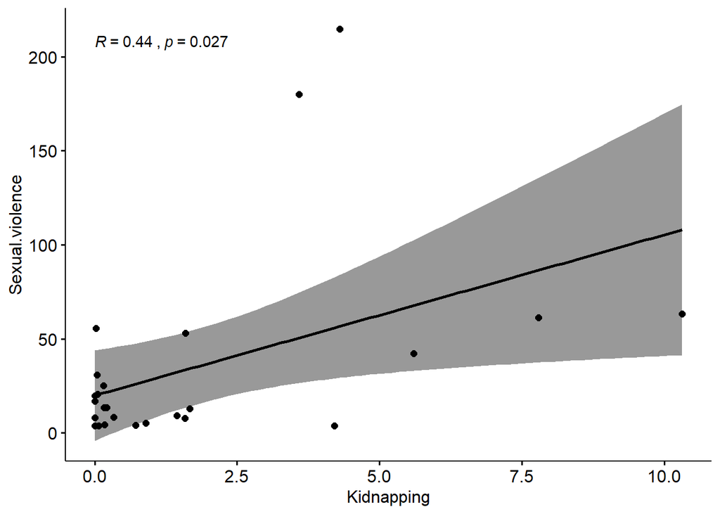

```r
library("ggpubr")
ggscatter(EuroCrime_new,x="Kidnapping",y="Sexual.violence",
          add ="reg.line",conf.int=TRUE,
          cor.coef = TRUE, cor.method= "pearson")
```